# Retention Index Normal Adjustment

Degnan, David J. & Bramer, Lisa M. & Flores, Javier E.

Last updated: 09/23/2022

# 1 Adjusting Normal Distribution Assumptions

## 1.1 Results Summary

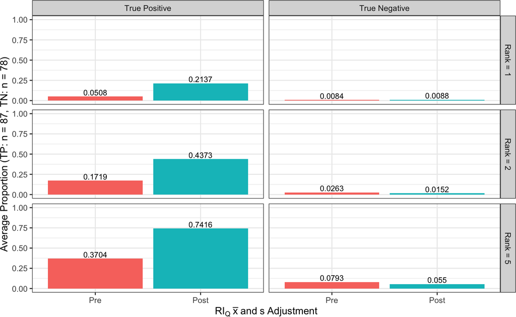

**Figure 1: Average proportion of true positives (n = 87) and true negatives (n = 78) at ranks 1, 2, and 5.**

We see definite improvement with this approach for true positives at ranks 1, 2, and 5 with 4, 2.5, and 2-fold changes, respectively. We do not see any improvement for true negatives at rank 1, but we do see improvements at ranks 2 and 5 (**Fig. 1**). This plot only shows general trends overall, following the adjustment of the retention index score to each metabolite’s estimated retention index mean and standard deviation. The trelliscope display (Trelli1) shows the trends per metabolite. Below, we have a single example of these trends.

## 1.2 Single Example

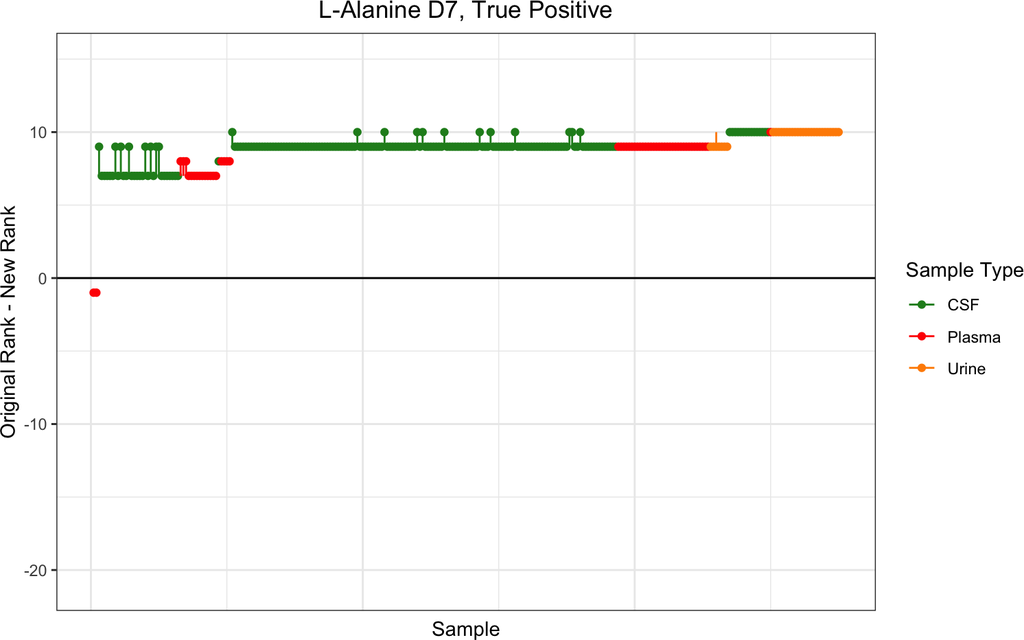

**Figure 2: An example from the trelliscope display of the true positive rank change distribution following our normal distribution adjustment. The point is the median rank change, and the line shows the range of rank changes.**

In L-Alanine D7, we see improvements in the rankings of the true positives for most of the samples, as a decrease in rank is desirable (**Fig. 2**). Sample type may have an effect on a per metabolite basis, as the trelliscope shows that fungal and soil samples often perform worse than CSF, Plasma, and Urine samples with this adjustment, though the trends vary widely per metabolite.

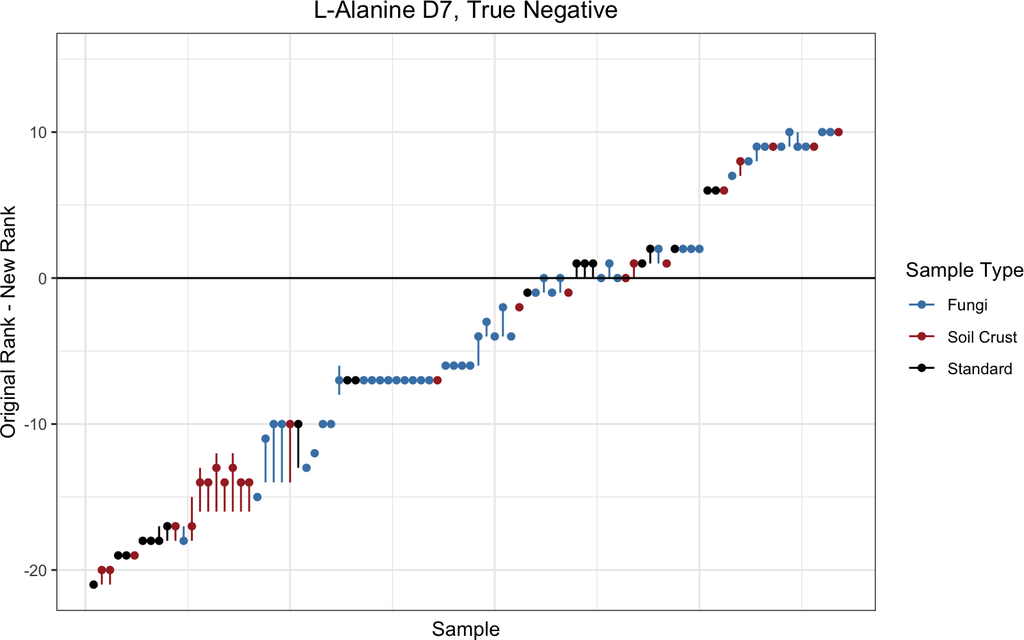

## 1.3 Rank Change

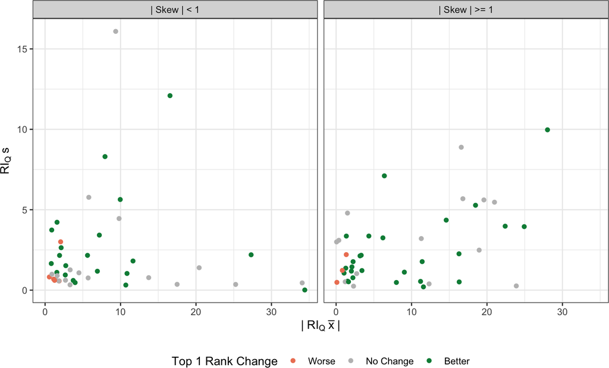

**Figure 4: True positive retention index difference (query minus reference) standard deviations plotted against absolute means and separate by skews less than or greater than 1. Points are colored by rank change improvements at rank 1, where better >= 0.05, worse is <= -0.05, and the rest are labeled no change.**

There is no obvious trend between improvement at rank 1 and query retention index statistics (mean, standard deviation, and skew) (**Fig. 4**). This means that our three summary statistics alone do not fully describe what makes a good rank change. That said, adjusting the score with higher means and standard deviations generally results in no change or better scores.

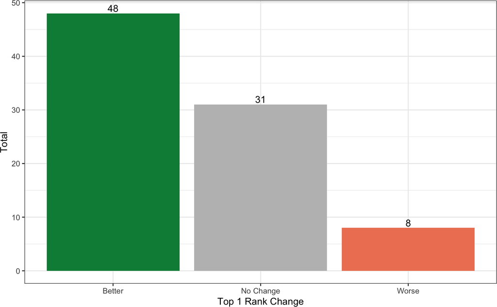

**Figure 5: Counts of changes at rank 1 using this adjustment, where better >= 0.05, worse is <= -0.05, and the rest are labeled no change.**

With this approach, 55% of our 87 metabolite subset have better rankings, 36% experience no change, and 9% have worse rankings (**Fig. 5**). Next, we will try using the normal distribution probabilities instead of the kernel as the RI score. See the next markdown for more details.

# 2 Publication Figure

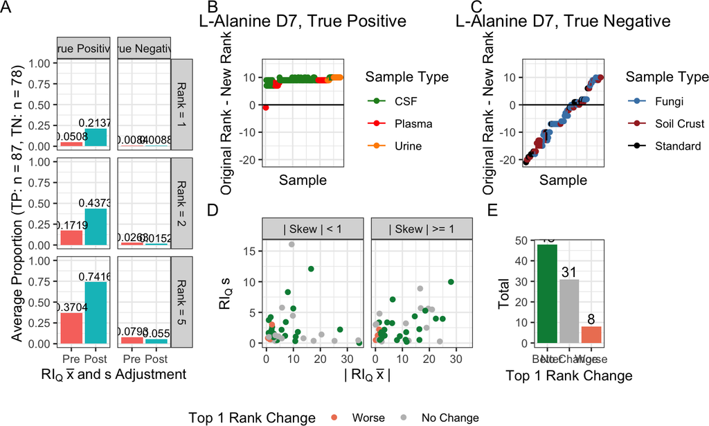